# General pattern of phenotypic mean

Keisuke Atsumi

20/06/16 11:38

# Setup

## Custom functions

```r
> #' Title: the function to get prediction intervals (crediblity intervals) from rma objects (metafor)
> #'
> #' @param model: rma.mv object
> #' @param mod: the name of a moderator
> get_pred <- function(model, mod = " ") {
+   I2 <- i2_ml(model) %>%
+     as.data.frame() %>%
+     rownames_to_column("Partition") %>%
+     rename("I2" = ".") %>%
+     mutate(percentage = str_c(round(I2*100,1),"%", sep = "")) %>%
+     column_to_rownames("Partition")
+
+   name <- as.factor(str_replace(row.names(model$beta), mod, ""))
+   len <- length(name)
+
+   if (len != 1) {
+       newdata <- matrix(NA, ncol = len, nrow = len)
+       for (i in 1:len) {
+           # getting the position of unique case from X (design matrix)
+           pos <- which(model$X[, i] == 1)[[1]]
+           newdata[, i] <- model$X[pos, ]
+       }
+       pred <- predict.rma(model, newmods = newdata)
+     } else {
+         pred <- predict.rma(model)
+     }
+
+     table <- tibble(
+       'Dataset' = "",
+       'Fixed effects' = name,
+       'Estimate' = model$beta, # regression: estimate
+       'LowerCI' = model$ci.lb, # regression: 95ci,
+       'UpperCI'  = model$ci.ub, # regression: 95ci
+       'lowerPR' = pred$cr.lb,  # lower prediction range
+       'upperPR' = pred$cr.ub, # lower prediction range
+       'P'        = model$pval,
+     # 'V[species with phylogeny]' =
+     #   c(model$sigma2[1], rep("", length(model$beta))),
+     # 'V[study]' =
+     #   c(model$sigma2[2], rep("", length(model$beta))),
+     # 'V[crossed strain]' =
+     #   c(model$sigma2[3], rep("", length(model$beta))),
+     # 'V[residual]' =
+     #   c(model$sigma2[4], rep("", length(model$beta))),
+     'I2[total]' =
+       c(I2["I2_total","percentage"], rep("", length(model$beta)-1)),
+     '%I2[species with phylogeny]' =
+       c(I2["I2_spL.name","percentage"], rep("", length(model$beta)-1)),
+     '%I2[study]' =
+       c(I2["I2_Study.ID","percentage"], rep("", length(model$beta)-1)),
+     '%I2[crossed strain]' =
+       c(I2["I2_Cross.ID","percentage"], rep("", length(model$beta)-1)),
+     '%I2[residual]' =
+       c(I2["I2_ES.ID","percentage"], rep("", length(model$beta)-1)),
+     )  %>%
+     as.data.frame() %>%
+     mutate_at(vars('Estimate':'P'), as.numeric) %>%
+     mutate(significance = ifelse(P < 0.05, "*", ""))
+ }
>
> #' Title: the function to get summary stats from rma objects (metafor)
> #'
> #' @param model: rma.mv object
> #' @param mod: the name of a moderator
> get_stats <- function(model, mod = " ") {
+
+     table <- tibble(
+       'Fixed_effects' = row.names(model$beta),
+       'Estimate' = model$beta, # regression: estimate
+       'LowerCI' = model$ci.lb, # regression: 95ci,
+       'UpperCI'  = model$ci.ub, # regression: 95ci
+       'P'        = model$pval
+       )  %>%
+       as.data.frame() %>%
+       mutate(significance = ifelse(P < 0.05, "*", ""))
+ }
>
>
> #' Title: the function to get summary stats from rma objects (metafor)
> #'
> #' @param model: rma.mv object
> #' @param mod: the name of a moderator
> get_reg <- function(model, mod = " ") {
+
+   I2 <- i2_ml(model) %>%
+     as.data.frame() %>%
+     rownames_to_column("Partition") %>%
+     rename("I2" = ".") %>%
+     mutate(percentage = str_c(round(I2*100,1),"%", sep = "")) %>%
+     column_to_rownames("Partition")
+
+   table <- tibble(
+     'Dataset' = "",
+     'Fixed effects' = c("", row.names(model$beta)),
+     'Estimate' = c("", model$beta), # regression: estimate
+     'LowerCI' = c("", model$ci.lb), # regression: 95ci,
+     'UpperCI'  = c("", model$ci.ub), # regression: 95ci
+     'P'        = c("", model$pval),
+     # 'V[species with phylogeny]' =
+     #   c(model$sigma2[1], rep("", length(model$beta))),
+     # 'V[study]' =
+     #   c(model$sigma2[2], rep("", length(model$beta))),
+     # 'V[crossed strain]' =
+     #   c(model$sigma2[3], rep("", length(model$beta))),
+     # 'V[residual]' =
+     #   c(model$sigma2[4], rep("", length(model$beta))),
+     'I2[total]' =
+       c(I2["I2_total","percentage"], rep("", length(model$beta))),
+     '%I2[species with phylogeny]' =
+       c(I2["I2_spL.name","percentage"], rep("", length(model$beta))),
+     '%I2[study]' =
+       c(I2["I2_Study.ID","percentage"], rep("", length(model$beta))),
+     '%I2[crossed strain]' =
+       c(I2["I2_Cross.ID","percentage"], rep("", length(model$beta))),
+     '%I2[residual]' =
+       c(I2["I2_ES.ID","percentage"], rep("", length(model$beta))),
+     )  %>%
+     as.data.frame() %>%
+     mutate_at(vars('Estimate':'P'), as.numeric) %>%
+     mutate(significance = ifelse(P < 0.05, "*", ""))
+ }
```

## Load data

```r
> ### Phenotypic and metadata ###
>
> # Load effect sizes
> mean.dif <- read.csv("../data/mean.ES.general.csv", head = TRUE) %>%
+   # indicate dataset including TS
+   mutate(data.type = "withTS")
>
> # Observations with TS
> TS <- read.csv("../data/mean.ES.TS.csv", head = TRUE) %>%
+   filter(lnRR.es < 0) %>%
+   distinct(ES.ID)
> # Effect sizes without observations with TS
> noTS <- read.csv("../data/mean.ES.general.csv", head = TRUE) %>%
+   filter(!(ES.ID %in% TS$ES.ID)) %>%
+   # indicate dataset without TS
+   mutate(data.type = "withoutTS")
>
> # combine dataset with/without TS
> with.without.TS <- bind_rows(mean.dif, noTS) %>%
+   mutate(metaunit =  str_c(data.type, cross, sep = "_"))%>%
+   # Use observations with both reciprocal crosses
+   drop_na(contains("Mn"), contains("SD")) %>%
+   # Insect or no
+   mutate(
+     insect = ifelse(taxa %in% c("Cichliformes", "Anura", "Aves", "Rodentia"), "no", "insect"),
+   )
>
>
> ### Phylogeny ###
>
> # compute branch lengths of tree
> phylo_branch <- read.tree(file = "../data/phylo.mean.general.tre") %>%
+   compute.brlen(bin.tree, method = "Grafen", power = 1)
>
> # saving phylogeneic matrix
> phylo_cor <- vcv(phylo_branch, cor = T)
>
> # generating inverse phylogenetic matrix for MCMCglmm
> # Note one of the tips is called "Lates calcarifer (estimated)"
> phylo_branch$node.label <- NULL
> phylo_MCMC <- MCMCglmm::inverseA(phylo_branch, nodes = "ALL", scale = TRUE)$Ainv
>
>
> # Calculate midparent
> midparent <- with.without.TS %>%
+   # Divide mean by 2 in spL whereas hybrids are constant
+   mutate(
+     lnRR.midparent.es =
+       ifelse(
+         cross == "spL",
+         log(((Mn.spL + Mn.spS)/2)/Mn.spS), lnRR.es
+         )
+     # Divide variance by 4 in spL whereas hybrids are constant
+     ) %>%
+   mutate_at("cross", as.factor) %>%
+   within(levels(cross) <- c("hybLS", "hybSL", "midparent"))
```

# Assessing dominance

Compare midparent and hybrids by comparing phenotypic difference from spS to midparent (spL+spS/2) and to hybrids.  
phenotypic difference from spS to midparent: *ln((spL+spS/2)/SS)*  
phenotypic difference from spS to hybrids: *ln(hyb/SS)*  
As the variance of *ln((spL+spS/2)/SS)*, we use the variance of *ln(LL/SS)* for simplicity

```r
> for (j in c("withTS", "withoutTS")) {
+   for (k in c("alltaxon", "insect")) {
+
+     if (k == "alltaxon") {
+       dat <- midparent %>%
+         filter(data.type == j)
+     } else {
+       dat <- midparent %>%
+         filter(data.type == j, insect == k)
+     }
+
+     # ### phylogenetic random regresson comparing with midparent ###
+     # midparent.compare <- rma.mv(
+     #   yi = lnRR.midparent.es,
+     #   V = lnRR.sv,
+     #   data = dat,
+     #   method = "REML",
+     #   random = list(~1 | spL.name, ~1 | Study.ID, ~1 | Cross.ID, ~1 | ES.ID),
+     #   R = list(spL.name = phylo_cor),
+     #   mods = ~ relevel(cross, ref = "midparent")
+     #   )
+     # ### Save model ###
+     # saveRDS(
+     #   midparent.compare,
+     #   file = paste("../Analysis/Mean.midparent.compare", j, k, "obj", sep = ".")
+     #   )
+
+     ### Load model ###
+     midparent.compare <- readRDS(paste("../Analysis/Mean.midparent.compare", j, k, "obj", sep = "."))
+
+     assign(
+       paste("Dominance", j,k, sep = "."),
+       get_reg(midparent.compare) %>%
+         # Show dataset name
+         within(Dataset <- c(paste(j,k), rep("", length(.$Estimate)-1))) %>%
+         # Rename fixed effects
+         within('Fixed effects' <- c("", "midparent (intrcpt)", "hybLS", "hybSL")) %>%
+         # Difference with midparent in %
+         mutate('Comparison with midparent' = c(
+           rep("", 2),
+           paste(
+             round(
+             100*(exp(midparent.compare$beta[1]+midparent.compare$beta[2])            -exp(midparent.compare$beta[1])), # hybrid LS
+             2),
+             "% larger"
+             ),
+           paste(
+             round(
+             100*(exp(midparent.compare$beta[1]+midparent.compare$beta[3])-exp(midparent.compare$beta[1])), # hybrid SL
+             2),
+             "% larger"
+             )
+           ))
+       )
+
+     # ### Meta-analysis for midparent to plot band ###
+     # midparent.random <- rma.mv(
+     #   yi = lnRR.midparent.es,
+     #   V = lnRR.sv,
+     #   data = dat %>% filter(cross == "midparent"),
+     #   method = "REML",
+     #   random = list(~1 | spL.name, ~1 | Study.ID, ~1 | Cross.ID, ~1 | ES.ID),
+     #   R = list(spL.name = phylo_cor)
+     #   )
+     # ### Save model ###
+     # saveRDS(
+     #   midparent.random,
+     #   file = paste("../Analysis/Mean.midparent", j, k, "obj", sep = ".")
+     #   )
+
+     ### Load model ###
+     midparent.random <- readRDS(paste("../Analysis/Mean.midparent", j, k, "obj", sep = "."))
+     # creating summary table of results
+     assign(
+       paste("midparent.ma", j, k, sep = "."),
+       # Prediction interval of midparent
+       get_pred(midparent.random) %>%
+         as.data.frame() %>%
+         mutate(
+           data.type = j,
+           taxon = k
+           )
+     )
+
+   }
+ }
>
> bind_rows(
+   Dominance.withTS.alltaxon, Dominance.withoutTS.alltaxon,
+   Dominance.withTS.insect, Dominance.withoutTS.insect
+   ) %>%
+   kable("html", digits = 3) %>% kable_styling("striped", position = "left")
```

Dataset

Fixed effects

Estimate

LowerCI

UpperCI

P

I2[total]

%I2[species with phylogeny]

%I2[study]

%I2[crossed strain]

%I2[residual]

significance

Comparison with midparent

withTS alltaxon

99.7%

41.3%

0%

0%

58.4%

midparent (intrcpt)

0.580

0.256

0.903

0

hybLS

-0.073

-0.079

-0.067

0

-12.55 % larger

hybSL

-0.100

-0.106

-0.093

0

-16.93 % larger

withoutTS alltaxon

99.8%

39%

0%

0%

60.8%

midparent (intrcpt)

0.628

0.287

0.969

0

hybLS

-0.107

-0.114

-0.100

0

-19.01 % larger

hybSL

-0.138

-0.145

-0.131

0

-24.17 % larger

withTS insect

99.6%

0%

10%

0%

89.6%

midparent (intrcpt)

0.396

0.306

0.486

0

hybLS

-0.073

-0.079

-0.066

0

-10.42 % larger

hybSL

-0.100

-0.106

-0.094

0

-14.15 % larger

withoutTS insect

99.7%

0%

10.6%

0%

89%

midparent (intrcpt)

0.444

0.336

0.552

0

hybLS

-0.107

-0.114

-0.100

0

-15.8 % larger

hybSL

-0.139

-0.146

-0.132

0

-20.22 % larger

```r
> ### Midparent meta-analysis result for plot below ###
> midparent.ma <- bind_rows(
+   midparent.ma.withTS.alltaxon, midparent.ma.withoutTS.alltaxon,
+   midparent.ma.withTS.insect, midparent.ma.withoutTS.insect
+ )
```

# Meta-analysis for each hybrids and parental

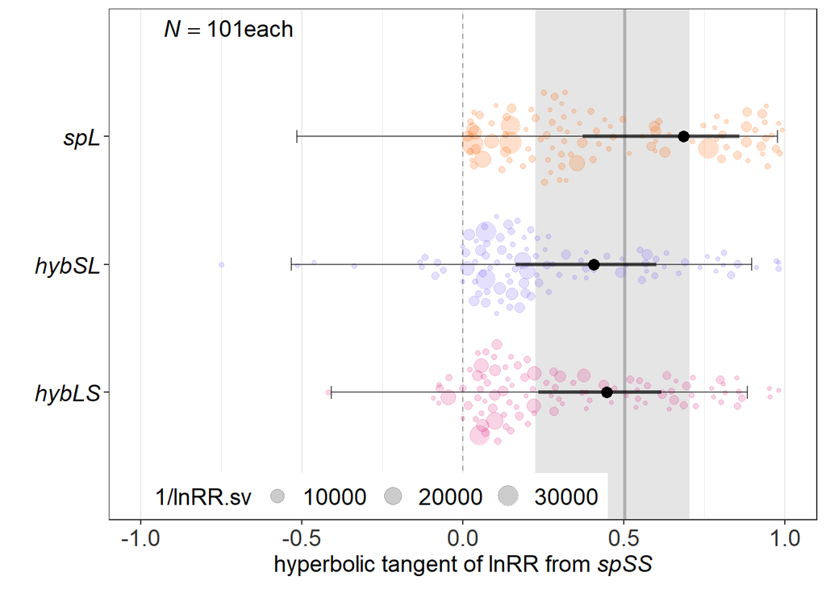

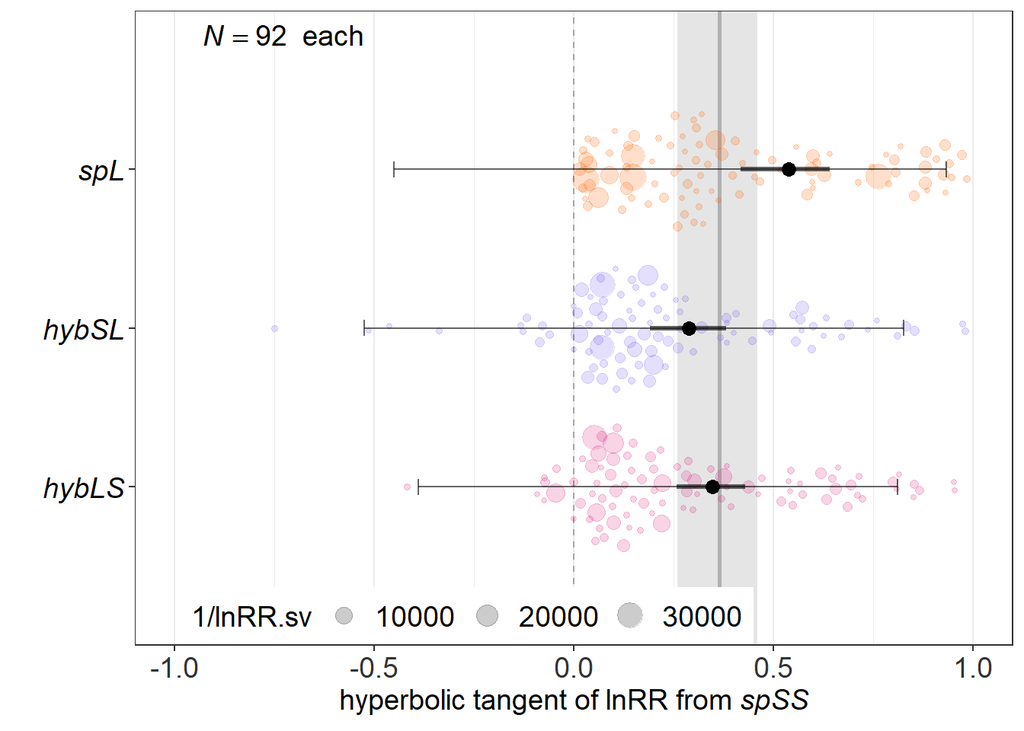

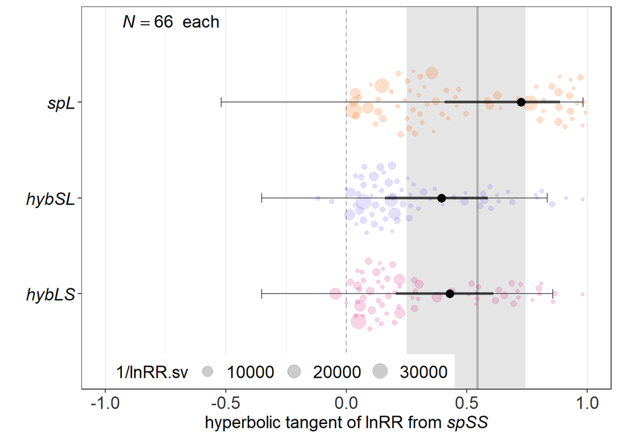

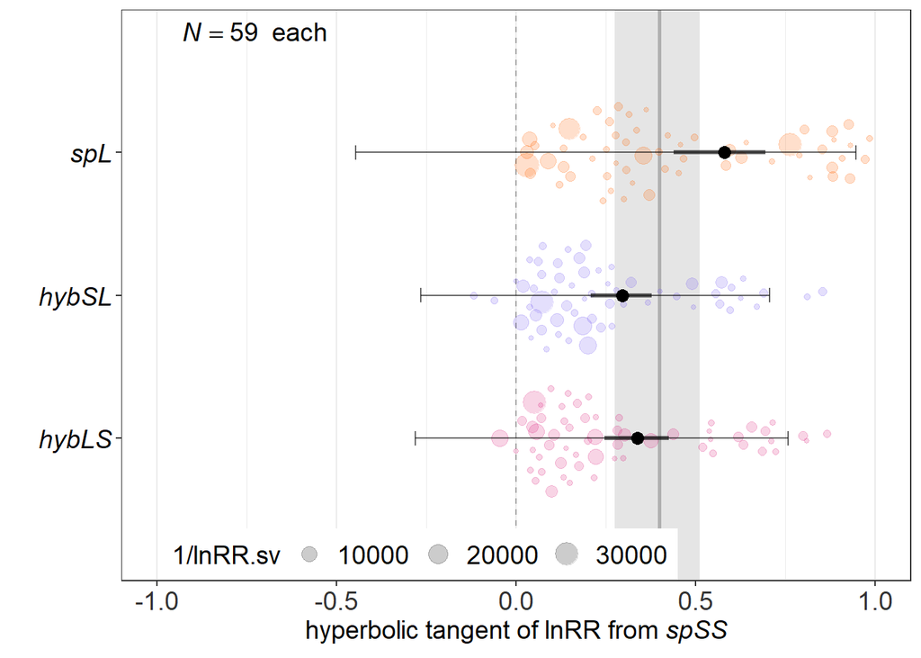

```r
> for (j in c("withTS", "withoutTS")) {
+   for (k in c("alltaxon", "insect")) {
+     for (h in c("spL", "hybLS", "hybSL")) {
+
+       if (k == "alltaxon") {
+         dat <- with.without.TS %>%
+           filter(cross == h, data.type == j)
+       } else {
+         dat <- with.without.TS %>%
+           filter(cross == h, data.type == j, insect == k)
+       }
+
+       # # Phylogenetic random meta-analysis
+       # phyl.random <- rma.mv(
+       #   yi = lnRR.es, V = lnRR.sv,
+       #   data = dat, method = "REML",
+       #   random = list(
+       #     ~1 | spL.name, ~1 | Study.ID, ~1 | Cross.ID, ~1 | ES.ID
+       #     ),
+       #   R = list(spL.name = phylo_cor)
+       #   )
+       # saveRDS(phyl.random,
+       #   file = paste("../Analysis/Mean.meta", j, k, h, "obj", sep = "."))
+
+
+       ### Load model ###
+       phyl.random <- readRDS(paste("../Analysis/Mean.meta", j, k, h, "obj", sep = "."))
+       # Funnel plot
+       # funnel(phyl.random, xlab = paste(j, k, h))
+       # creating summary table of results
+       assign(
+         paste("res", h, sep = "."),
+         get_pred(phyl.random) %>%
+           as.data.frame() %>%
+           mutate(
+             N = length(dat$ES.ID),
+             # I2 = I2(phyl.random)["I2_total"] %>% round(3),
+             cross = h # indicate cross (spL, hybLS, hybSL)
+             )
+           )
+
+     }
+
+     if (k == "alltaxon") {
+       dat.plot <- with.without.TS %>%
+         filter(data.type == j)
+     } else {
+       dat.plot <- with.without.TS %>%
+         filter(data.type == j, insect == k)
+     }
+
+     # Bind result of all crosses at each dataset
+     assign(
+       paste("res.ma", j,k, sep = "."),
+       res.ma <- bind_rows(
+         res.spL, res.hybLS, res.hybSL
+         ) %>%
+         as.data.frame() %>%
+         within('Dataset' <- c(paste(j,k), "", "")) # dataset name in first row
+     )
+
+     ### Midparent estimate & CI ###
+     midparent.ma.2 <- midparent.ma %>%
+       filter(data.type == j, taxon == k)
+
+     # creating a forest plot
+     plot.metamean <- ggplot(
+       data = res.ma,
+       aes(x = tanh(Estimate), y = cross)
+       ) +
+       scale_y_discrete(expand = c(0, 1)) +
+       scale_x_continuous(
+         limits = c(-1, 1),
+         breaks = seq(-1, 1, by = 0.5)
+         ) +
+       ### Midparent CI ###
+       geom_rect(
+         aes(
+           xmin = tanh(midparent.ma.2$LowerCI),
+           xmax = tanh(midparent.ma.2$UpperCI),
+           ymin = -Inf, ymax = Inf
+           ),
+         fill="Grey 90"
+         ) +
+       ### Midparent estimate ###
+       geom_vline(
+         xintercept = tanh(midparent.ma.2$Estimate), colour = "grey20",
+         alpha = 0.3, size = 1
+         ) +
+       ### Orchard plot ###
+       geom_quasirandom(
+         data = dat.plot,
+         aes(x = tanh(lnRR.es), y = cross, size = 1/lnRR.sv, color = cross),
+         alpha = 0.2, groupOnX = FALSE
+         ) +
+       scale_color_manual(values = c("#DC267F", "#785EF0", "#FE6100")) +
+       # Delete legend for colors
+       guides(fill = "none", colour = "none") +
+       # Confidential interval : thicker line
+       geom_errorbarh(
+         aes(xmin = tanh(LowerCI), xmax = tanh(UpperCI)),
+         height = 0, size = 1.2, alpha = 0.6
+         ) +
+       # Prediction interval : thinner line
+       geom_errorbarh(
+         aes(xmin = tanh(lowerPR), xmax = tanh(upperPR)),
+         height = 0.1, size = 0.5, alpha = 0.6
+         ) +
+       geom_vline(xintercept = 0, linetype = 2, colour = "black", alpha = 0.3) +
+       ### Estimate ###
+       geom_point(size = 3, shape = 21, fill = "black") +
+       # ### I^2 ###
+       # annotate(
+       #   "text", x = -0.93, y = c(1.35, 2.35, 3.35),
+       #   label = paste("italic(I^2)==", res.ma$I2),
+       #   parse = TRUE, hjust = "left", size = 5
+       # ) +
+       ### N ###
+       annotate(
+         "text", x = -0.93, y = 3.85,
+         label = paste("italic(N)==", length(dat.plot$ES.ID)/3),
+         parse = TRUE, hjust = "left", size = 5
+       ) +
+       annotate(
+         "text", x = -0.68, y = 3.85,
+         label = "each", hjust = "left", size = 5
+       ) +
+       ylab("") +
+       xlab(expression(
+         paste("hyperbolic tangent of lnRR from ", italic("spSS")),
+         parse = TRUE
+         )) +
+       theme_bw() +
+       theme(
+         panel.grid.major.y = element_blank(),
+         axis.text.y = element_text(size = 14, color = "black", face = "italic"),
+         axis.text.x = element_text(size = 14, color = "grey20"),
+         axis.title = element_text(size = 14, color = "black"),
+         legend.position = c(0.15, 0.002),
+         legend.justification = c(0.15, 0.002),
+         legend.text = element_text(size = 14),
+         legend.title = element_text(size = 14),
+         legend.direction = "horizontal"
+         )
+
+     print(plot.metamean)
+
+
+     ggsave(
+       plot = plot.metamean,
+       file = paste("../Analysis/mean.general.metamean", j,k, "svg", sep = "."),
+       height = 4, width = 5
+       )
+   }
+ }
```

```r
> bind_rows(
+   res.ma.withTS.alltaxon, res.ma.withoutTS.alltaxon,
+   res.ma.withTS.insect, res.ma.withoutTS.insect
+   ) %>%
+   as.data.frame() %>%
+   # mutate_at(vars('Estimate':'%I2[residual]'), as.numeric) %>%
+   # select(Dataset, cross, Estimate, UpperCI, LowerCI, contains("PR"), contains("I2")) %>%
+   kable("html", digits = 3) %>% kable_styling("striped", position = "left")
```

Dataset

Fixed effects

Estimate

LowerCI

UpperCI

lowerPR

upperPR

P

I2[total]

%I2[species with phylogeny]

%I2[study]

%I2[crossed strain]

%I2[residual]

significance

N

cross

withTS alltaxon

intrcpt

0.842

0.392

1.292

-0.571

2.254

0.000

99.9%

31.6%

5.7%

0%

62.7%

101

spL

intrcpt

0.481

0.240

0.721

-0.433

1.394

0.000

99.7%

18.5%

1.6%

0%

79.6%

101

hybLS

intrcpt

0.432

0.167

0.697

-0.594

1.457

0.001

99.8%

17.6%

1.8%

0%

80.4%

101

hybSL

withoutTS alltaxon

intrcpt

0.922

0.434

1.410

-0.576

2.420

0.000

99.9%

31.7%

7.4%

0%

60.8%

66

spL

intrcpt

0.460

0.210

0.710

-0.367

1.287

0.000

99.7%

25.6%

0%

0%

74.1%

66

hybLS

intrcpt

0.419

0.162

0.675

-0.367

1.204

0.001

99.6%

31.5%

1.1%

0%

67.1%

66

hybSL

withTS insect

intrcpt

0.604

0.446

0.762

-0.486

1.693

0.000

99.9%

0%

12.3%

0%

87.6%

92

spL

intrcpt

0.362

0.265

0.460

-0.411

1.135

0.000

99.6%

0%

3.8%

0%

95.9%

92

hybLS

intrcpt

0.298

0.193

0.402

-0.583

1.178

0.000

99.7%

0%

2.1%

0%

97.6%

92

hybSL

withoutTS insect

intrcpt

0.665

0.472

0.858

-0.480

1.810

0.000

99.9%

0%

16%

0%

83.9%

59

spL

intrcpt

0.353

0.252

0.454

-0.288

0.995

0.000

99.6%

0%

8.2%

0%

91.4%

59

hybLS

intrcpt

0.305

0.211

0.399

-0.271

0.881

0.000

99.5%

0%

10.7%

0%

88.7%

59

hybSL

# Comparing mean across all crosses

Comparing the differences between parentals and hybrids

```r
> for (j in c("withTS", "withoutTS")) {
+   for (k in c("alltaxon", "insect")) {
+
+     if (k == "alltaxon") {
+       dat <- with.without.TS %>%
+         filter(data.type == j)
+     } else {
+       dat <- with.without.TS %>%
+         filter(data.type == j, insect == k)
+     }
+
+     #+++++++++++++++++++++++++++++++++++++++++++++#
+     # phylogenetic random regresson (ANOVA)
+     #+++++++++++++++++++++++++++++++++++++++++++++#
+     # # Regress by lnRR of phenotypic difference between parentals
+     # phyl.random.spL <- rma.mv(
+     #   yi = lnRR.es, V = lnRR.sv,
+     #   data = dat, method = "REML",
+     #   random = list(~1 | spL.name, ~1 | Study.ID, ~1 | Cross.ID, ~1 | ES.ID),
+     #   R = list(spL.name = phylo_cor),
+     #   mods = ~ relevel(cross, ref = "spL")
+     #   )
+     # phyl.random.hybLS <- rma.mv(
+     #   yi = lnRR.es, V = lnRR.sv,
+     #   data = dat, method = "REML",
+     #   random = list(~1 | spL.name, ~1 | Study.ID, ~1 | Cross.ID, ~1 | ES.ID),
+     #   R = list(spL.name = phylo_cor),
+     #   mods = ~ cross
+     #   )
+     # # Save model ###
+     # saveRDS(
+     #   phyl.random.spL,
+     #   file = paste("../Analysis/Mean.compare.from.spL", j, k, "obj", sep = ".")
+     #   )
+     # saveRDS(
+     #   phyl.random.hybLS,
+     #   file = paste("../Analysis/Mean.compare.from.hybLS", j, k, "obj", sep = ".")
+     #   )
+
+     ## Load model ###
+     phyl.random.spL <- readRDS(paste("../Analysis/Mean.compare.from.spL", j, k, "obj", sep = "."))
+     phyl.random.hybLS <- readRDS(paste("../Analysis/Mean.compare.from.hybLS", j, k, "obj", sep = "."))
+
+   assign(
+     paste("Reciprocal", j,k, sep = "."),
+     get_reg(phyl.random.hybLS) %>%
+       # Show dataset name
+       within(Dataset <- c(paste(j,k), rep("", length(.$Estimate)-1))) %>%
+       # Rename fixed effects
+       within('Fixed effects' <- c("", "hybLS (intrcpt)", "hybSL", "spLL")) %>%
+       # Difference with midparent in %
+       mutate('Comparison with hybridLS' = c(
+         rep("", 2),
+         paste(
+           round(
+             (exp(phyl.random.hybLS$beta[1]+phyl.random.hybLS$beta[2]) -
+                exp(phyl.random.hybLS$beta[1])
+              )*100,
+             2),
+           "% larger"
+           ),
+         ""
+         )
+       )
+     )
+   }
+ }
>
> bind_rows(
+   Reciprocal.withTS.alltaxon, Reciprocal.withoutTS.alltaxon,
+   Reciprocal.withTS.insect, Reciprocal.withoutTS.insect
+   ) %>%
+   kable("html", digits = 3) %>% kable_styling("striped", position = "left")
```

Dataset

Fixed effects

Estimate

LowerCI

UpperCI

P

I2[total]

%I2[species with phylogeny]

%I2[study]

%I2[crossed strain]

%I2[residual]

significance

Comparison with hybridLS

withTS alltaxon

99.8%

42.1%

1.3%

0%

56.4%

hybLS (intrcpt)

0.568

0.180

0.957

0.004

hybSL

-0.028

-0.035

-0.022

0.000

-4.95 % larger

spLL

0.240

0.233

0.246

0.000

withoutTS alltaxon

99.9%

40.8%

0%

0%

59%

hybLS (intrcpt)

0.579

0.167

0.990

0.006

hybSL

-0.034

-0.042

-0.027

0.000

-6.01 % larger

spLL

0.301

0.294

0.308

0.000

withTS insect

99.7%

0%

11.9%

0%

87.8%

hybLS (intrcpt)

0.349

0.239

0.460

0.000

hybSL

-0.029

-0.036

-0.022

0.000

-4.08 % larger

spLL

0.239

0.233

0.245

0.000

withoutTS insect

99.8%

0%

11.1%

0%

88.7%

hybLS (intrcpt)

0.355

0.226

0.483

0.000

hybSL

-0.035

-0.043

-0.028

0.000

-4.95 % larger

spLL

0.301

0.294

0.308

0.000

# Assesing maternal inheritance

Comparing the differences between parentals and hybrids  
Indicates that maternal inheritance become stronger in male-heterogametic species, but, dataset is heavily biased toward male-heterogametic species so this effect is still uncertain  
Included the analysis accomodating potential publication bias by including SE of effect size as a moderator

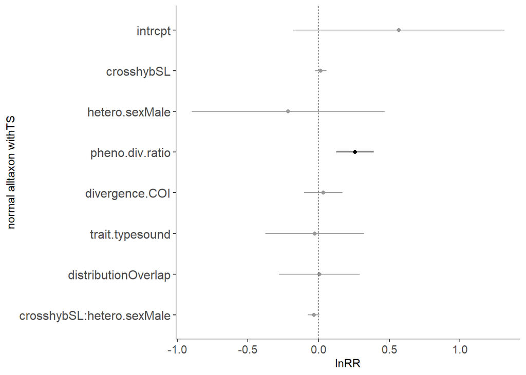

```r
> for (l in c("normal", "sensitivity")) {
+   for (j in c("withTS", "withoutTS")) {
+     for (k in c("alltaxon", "insect")) {
+
+       if (k == "alltaxon") {
+         dat <- with.without.TS %>%
+           filter(data.type == j, cross != "spL")
+       } else {
+         dat <- with.without.TS %>%
+           filter(data.type == j, insect == k, cross != "spL")
+       }
+
+       # if (l == "normal") {
+       # # Regress by lnRR of phenotypic difference between parentals
+       # phyl.random <- rma.mv(
+       #   yi = lnRR.es, V = lnRR.sv,
+       #   data = dat, method = "REML",
+       #   random = list(~1 | spL.name, ~1 | Study.ID, ~1 | Cross.ID, ~1 | ES.ID),
+       #   R = list(spL.name = phylo_cor),
+       #   mods = ~ cross*hetero.sex +
+       #     pheno.div.ratio + divergence.COI +
+       #     trait.type + distribution
+       #   )
+       # } else {
+       # # Regress by lnRR of phenotypic difference between parentals
+       # phyl.random <- rma.mv(
+       #   yi = lnRR.es, V = lnRR.sv,
+       #   data = dat, method = "REML",
+       #   random = list(~1 | spL.name, ~1 | Study.ID, ~1 | Cross.ID, ~1 | ES.ID),
+       #   R = list(spL.name = phylo_cor),
+       #   mods = ~ cross*hetero.sex +
+       #     pheno.div.ratio + divergence.COI +
+       #     trait.type + distribution +
+       #     sqrt(lnRR.sv)                       # add SE
+       #   )
+       # }
+       #
+       # saveRDS(
+       #   phyl.random,
+       #   file = paste("../Analysis/Mean.metareg", j, k, l, "obj", sep = ".")
+       #   )
+
+       ### Load model ###
+       phyl.random <- readRDS(paste("../Analysis/Mean.metareg", j, k, l, "obj", sep = "."))
+
+
+       ### Output result ###
+       reg <- get_stats(phyl.random) %>%
+         mutate_at("Fixed_effects", as.factor)
+       plot <- ggplot(reg, aes(y = Estimate, x = Fixed_effects)) +
+         geom_errorbar(
+           aes(ymin = LowerCI, ymax = UpperCI, colour=significance),
+           width=.0001
+           ) +
+         # Color of plots and errorbars
+         scale_colour_manual(values = c("grey60", "black")) +
+         geom_point(size = 1.5, aes(colour = significance)) +
+         scale_fill_manual(values = c("grey60", "black")) +
+         scale_x_discrete(limits = rev(reg$Fixed_effects))+ # reverse x-axis
+         geom_hline(yintercept = 0, linetype="dashed", size = 0.3) +
+         coord_flip() +
+         ylab("lnRR") + xlab(paste(l, k, j)) +
+         theme_bw() +
+         theme(
+           panel.grid = element_blank(),
+           legend.position = "none",
+           panel.border=element_blank(),
+           axis.text.x = element_text(size = 11),
+           axis.text.y = element_text(size = 12),
+           axis.line=element_line(colour = "grey70")
+           )
+       print(plot)
+
+       get_reg(phyl.random) %>%
+         mutate_if(is.numeric, round, 3) %>%
+         # Show dataset name
+         within(Dataset <- c(paste(j,k), rep("", length(.$Estimate)-1))) %>%
+         kable("html", digits = 3, caption = paste(l,j,k)) %>%
+         kable_styling("striped", position = "left") %>%
+         print()
+
+     }
+   }
+ }
```

normal withTS alltaxon

Dataset

Fixed effects

Estimate

LowerCI

UpperCI

P

I2[total]

%I2[species with phylogeny]

%I2[study]

%I2[crossed strain]

%I2[residual]

significance

withTS alltaxon

99.8%

0%

0%

0%

99.8%

intrcpt

0.568

-0.179

1.315

0.136

crosshybSL

0.015

-0.024

0.054

0.454

hetero.sexMale

-0.216

-0.898

0.467

0.536

pheno.div.ratio

0.257

0.124

0.390

0.000

divergence.COI

0.034

-0.102

0.170

0.628

trait.typesound

-0.028

-0.376

0.321

0.876

distributionOverlap

0.006

-0.279

0.291

0.967

crosshybSL:hetero.sexMale

-0.034

-0.074

0.006

0.094

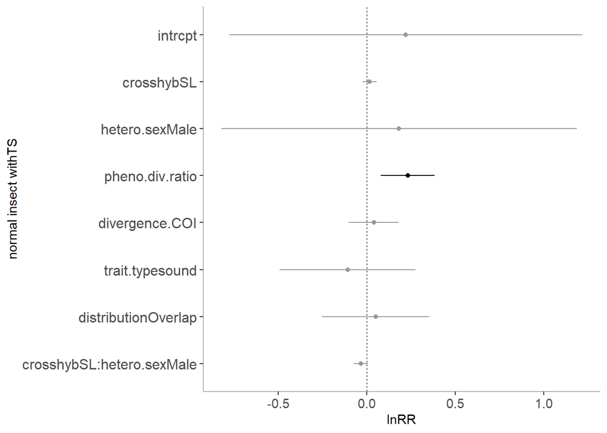

normal withTS insect

Dataset

Fixed effects

Estimate

LowerCI

UpperCI

P

I2[total]

%I2[species with phylogeny]

%I2[study]

%I2[crossed strain]

%I2[residual]

significance

withTS insect

99.8%

0%

0%

0%

99.8%

intrcpt

0.219

-0.777

1.215

0.667

crosshybSL

0.015

-0.024

0.054

0.459

hetero.sexMale

0.180

-0.824

1.184

0.725

pheno.div.ratio

0.230

0.078

0.383

0.003

divergence.COI

0.039

-0.103

0.181

0.590

trait.typesound

-0.109

-0.492

0.274

0.576

distributionOverlap

0.049

-0.254

0.352

0.753

crosshybSL:hetero.sexMale

-0.034

-0.074

0.006

0.096

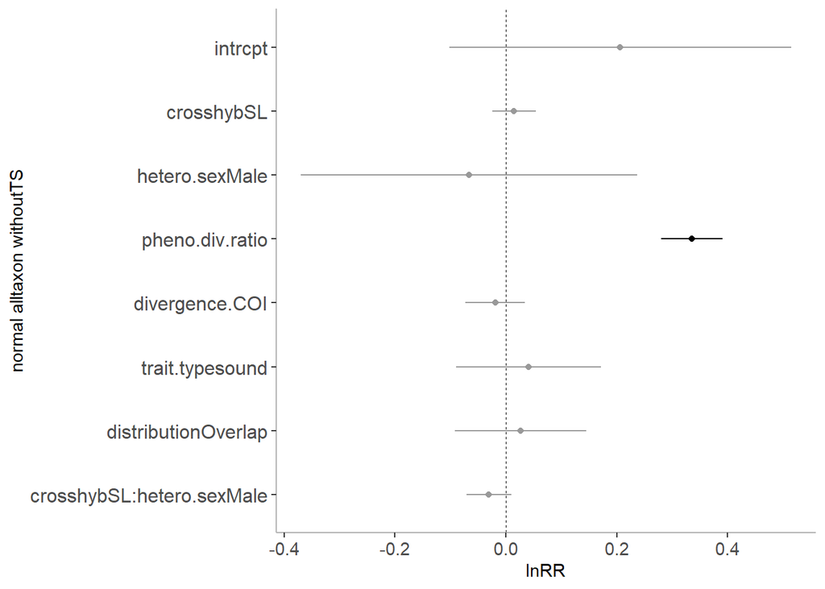

normal withoutTS alltaxon

Dataset

Fixed effects

Estimate

LowerCI

UpperCI

P

I2[total]

%I2[species with phylogeny]

%I2[study]

%I2[crossed strain]

%I2[residual]

significance

withoutTS alltaxon

98%

0%

0%

0%

98%

intrcpt

0.206

-0.102

0.515

0.190

crosshybSL

0.015

-0.024

0.054

0.459

hetero.sexMale

-0.067

-0.370

0.237

0.668

pheno.div.ratio

0.335

0.280

0.391

0.000

divergence.COI

-0.019

-0.073

0.034

0.478

trait.typesound

0.041

-0.090

0.172

0.541

distributionOverlap

0.026

-0.092

0.145

0.663

crosshybSL:hetero.sexMale

-0.031

-0.071

0.009

0.133

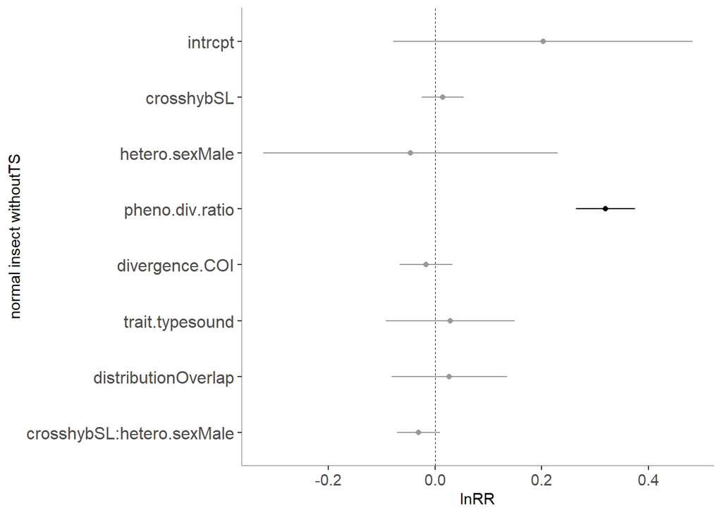

normal withoutTS insect

Dataset

Fixed effects

Estimate

LowerCI

UpperCI

P

I2[total]

%I2[species with phylogeny]

%I2[study]

%I2[crossed strain]

%I2[residual]

significance

withoutTS insect

97.8%

0%

0%

0%

97.8%

intrcpt

0.202

-0.078

0.483

0.157

crosshybSL

0.015

-0.024

0.054

0.459

hetero.sexMale

-0.046

-0.322

0.230

0.743

pheno.div.ratio

0.320

0.265

0.375

0.000

divergence.COI

-0.017

-0.066

0.033

0.511

trait.typesound

0.029

-0.092

0.149

0.642

distributionOverlap

0.027

-0.081

0.135

0.627

crosshybSL:hetero.sexMale

-0.031

-0.071

0.009

0.133

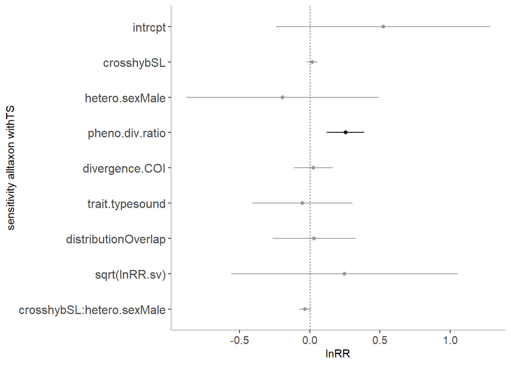

sensitivity withTS alltaxon

Dataset

Fixed effects

Estimate

LowerCI

UpperCI

P

I2[total]

%I2[species with phylogeny]

%I2[study]

%I2[crossed strain]

%I2[residual]

significance

withTS alltaxon

99.8%

0%

0%

0%

99.8%

intrcpt

0.522

-0.241

1.285

0.180

crosshybSL

0.016

-0.024

0.055

0.435

hetero.sexMale

-0.195

-0.882

0.492

0.578

pheno.div.ratio

0.254

0.120

0.388

0.000

divergence.COI

0.025

-0.114

0.164

0.726

trait.typesound

-0.055

-0.415

0.305

0.764

distributionOverlap

0.031

-0.265

0.327

0.839

sqrt(lnRR.sv)

0.248

-0.560

1.055

0.548

crosshybSL:hetero.sexMale

-0.035

-0.075

0.005

0.088

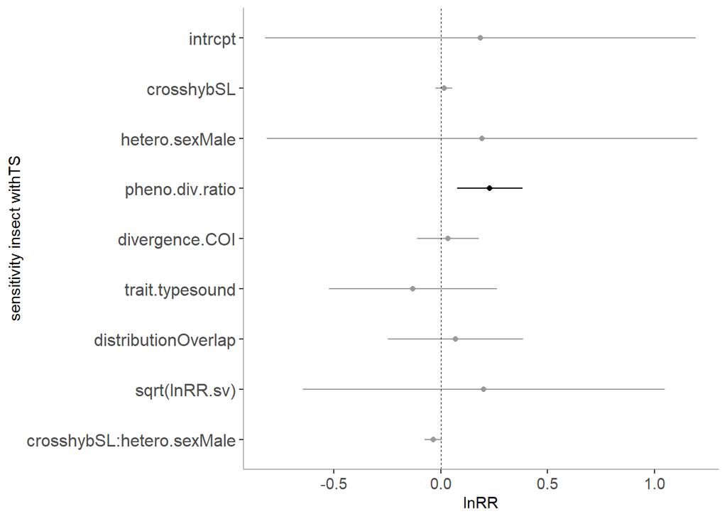

sensitivity withTS insect

Dataset

Fixed effects

Estimate

LowerCI

UpperCI

P

I2[total]

%I2[species with phylogeny]

%I2[study]

%I2[crossed strain]

%I2[residual]

significance

withTS insect

99.8%

0%

0%

0%

99.8%

intrcpt

0.186

-0.822

1.193

0.718

crosshybSL

0.015

-0.024

0.055

0.443

hetero.sexMale

0.193

-0.814

1.200

0.707

pheno.div.ratio

0.229

0.077

0.382

0.003

divergence.COI

0.033

-0.111

0.177

0.655

trait.typesound

-0.130

-0.523

0.263

0.517

distributionOverlap

0.070

-0.246

0.386

0.665

sqrt(lnRR.sv)

0.201

-0.644

1.047

0.641

crosshybSL:hetero.sexMale

-0.035

-0.075

0.006

0.091

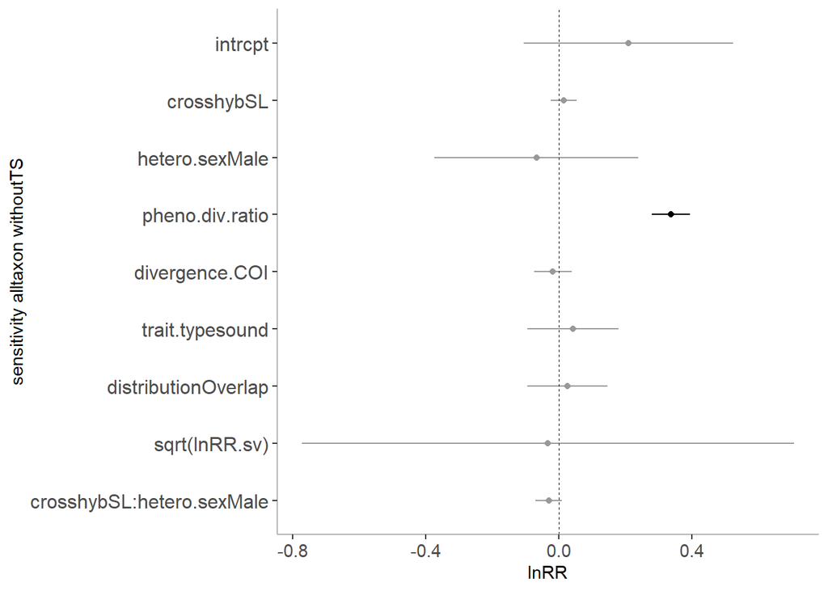

sensitivity withoutTS alltaxon

Dataset

Fixed effects

Estimate

LowerCI

UpperCI

P

I2[total]

%I2[species with phylogeny]

%I2[study]

%I2[crossed strain]

%I2[residual]

significance

withoutTS alltaxon

98%

0%

0%

0%

98%

intrcpt

0.209

-0.107

0.524

0.195

crosshybSL

0.015

-0.025

0.054

0.462

hetero.sexMale

-0.067

-0.374

0.239

0.667

pheno.div.ratio

0.336

0.278

0.394

0.000

divergence.COI

-0.019

-0.075

0.038

0.520

trait.typesound

0.042

-0.095

0.179

0.544

distributionOverlap

0.026

-0.094

0.146

0.670

sqrt(lnRR.sv)

-0.033

-0.773

0.706

0.930

crosshybSL:hetero.sexMale

-0.031

-0.071

0.010

0.135

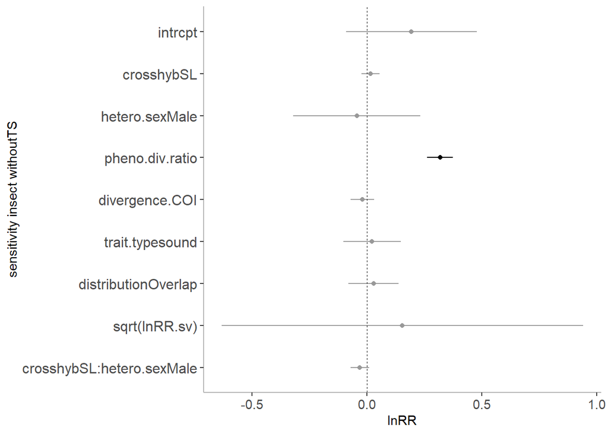

sensitivity withoutTS insect

Dataset

Fixed effects

Estimate

LowerCI

UpperCI

P

I2[total]

%I2[species with phylogeny]

%I2[study]

%I2[crossed strain]

%I2[residual]

significance

withoutTS insect

97.8%

0%

0%

0%

97.8%

intrcpt

0.193

-0.092

0.478

0.184

crosshybSL

0.015

-0.024

0.055

0.447

hetero.sexMale

-0.044

-0.321

0.233

0.754

pheno.div.ratio

0.318

0.262

0.374

0.000

divergence.COI

-0.020

-0.071

0.032

0.459

trait.typesound

0.022

-0.103

0.147

0.726

distributionOverlap

0.029

-0.080

0.137

0.607

sqrt(lnRR.sv)

0.154

-0.633

0.941

0.702

crosshybSL:hetero.sexMale

-0.031

-0.072

0.009

0.128

# Assesing maternal inheritance part 2

Comparing the differences between parentals and hybrids  
Model did not converge when data is restricted to without TS

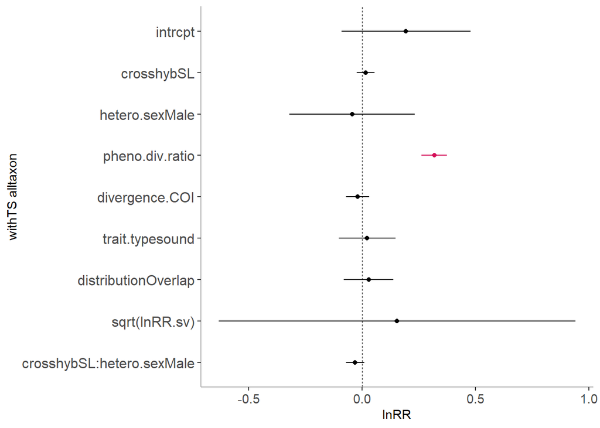

```r
> # Select ESs that can compare maternal and paternal inheritance
>
> for (j in c("withTS")) {
+   for (k in c("alltaxon", "insect")) {
+
+     if (k == "alltaxon") {
+       dat <- with.without.TS %>%
+         filter(data.type == j, cross != "spL") %>%
+         mutate(cross.sex = str_c(hetero.sex, cross, sep = "_"))
+     } else {
+       dat <- with.without.TS %>%
+         filter(data.type == j, insect == k, cross != "spL") %>%
+         mutate(cross.sex = str_c(hetero.sex, cross, sep = "_"))
+     }
+
+     # if (k == "insect" && j == "withoutTS") {
+     #
+     # } else {
+
+     ################################################
+     # phylogenetic random regresson (ANOVA)
+     ################################################
+     # phyl.random <- rma.mv(
+     #   yi = lnRR.es, V = lnRR.sv,
+     #   data = dat, method = "REML",
+     #   random = list(~1 | spL.name, ~1 | Study.ID, ~1 | Cross.ID, ~1 | ES.ID),
+     #   R = list(spL.name = phylo_cor),
+     #   mods = ~ pheno.div.ratio + cross.sex -1
+     #   )
+
+
+     ################################################
+     # Output result
+     ################################################
+
+     reg <- get_stats(phyl.random)
+
+     plot <- ggplot(reg, aes(y = Estimate, x = Fixed_effects)) +
+       geom_errorbar(
+         aes(ymin = LowerCI, ymax = UpperCI, colour=significance),
+         width=.0001
+         ) +
+       scale_colour_manual(values = c("black", "#D41159"), aesthetics = "colour") +
+       geom_point(aes(colour=significance))+
+       scale_fill_manual(values = c("black", "#D41159"), aesthetics = "colour") +
+       scale_x_discrete(limits = rev(reg$Fixed_effects))+ # reverse x-axis
+       geom_hline(yintercept = 0, linetype="dashed", size = 0.3) +
+       coord_flip() +
+       ylab("lnRR") + xlab(paste(j,k)) +
+         # Themes
+       theme_bw() +
+       theme(
+         panel.grid = element_blank(),
+         legend.position = "none",
+         panel.border=element_blank(),
+         axis.text.x = element_text(size = 11),
+         axis.text.y = element_text(size = 12),
+         axis.line=element_line(colour = "grey70")
+         )
+
+     print(plot)
+
+     get_reg(phyl.random) %>%
+       mutate_if(is.numeric, round, 3) %>%
+       # Show dataset name
+       within(Dataset <- c(paste(j,k), rep("", length(.$Estimate)-1))) %>%
+       kable("html", digits = 3, caption = paste(j,k)) %>%
+       kable_styling("striped", position = "left") %>%
+       print()
+
+     # }
+
+   }
+ }
```

withTS alltaxon

Dataset

Fixed effects

Estimate

LowerCI

UpperCI

P

I2[total]

%I2[species with phylogeny]

%I2[study]

%I2[crossed strain]

%I2[residual]

significance

withTS alltaxon

97.8%

0%

0%

0%

97.8%

intrcpt

0.193

-0.092

0.478

0.184

crosshybSL

0.015

-0.024

0.055

0.447

hetero.sexMale

-0.044

-0.321

0.233

0.754

pheno.div.ratio

0.318

0.262

0.374

0.000

divergence.COI

-0.020

-0.071

0.032

0.459

trait.typesound

0.022

-0.103

0.147

0.726

distributionOverlap

0.029

-0.080

0.137

0.607

sqrt(lnRR.sv)

0.154

-0.633

0.941

0.702

crosshybSL:hetero.sexMale

-0.031

-0.072

0.009

0.128

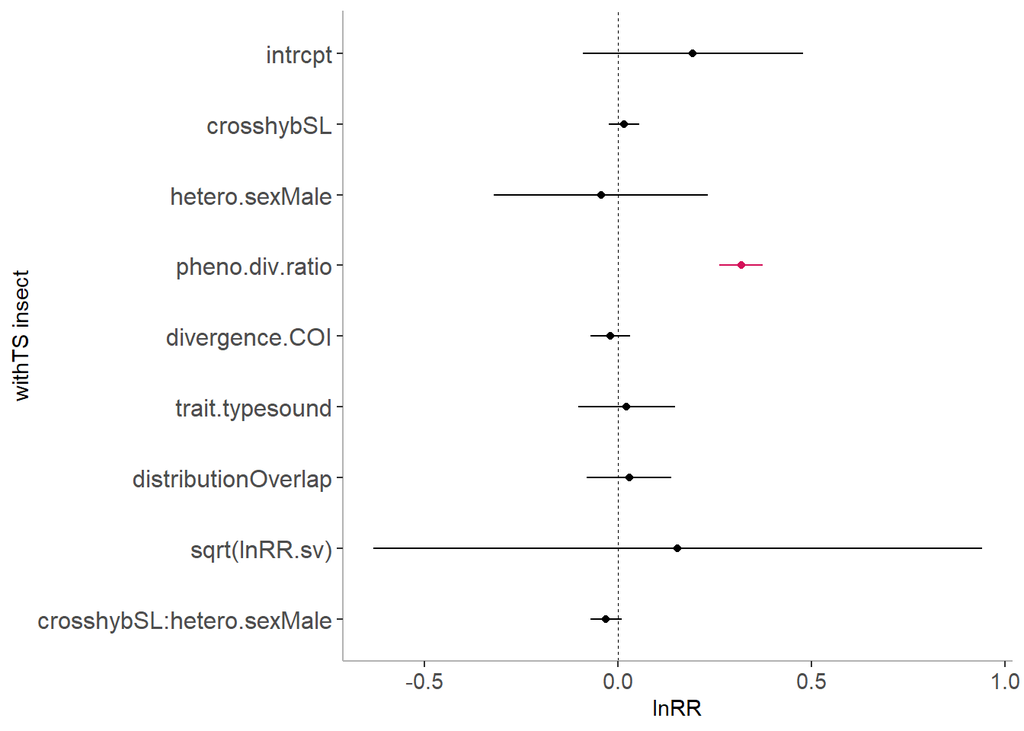

withTS insect

Dataset

Fixed effects

Estimate

LowerCI

UpperCI

P

I2[total]

%I2[species with phylogeny]

%I2[study]

%I2[crossed strain]

%I2[residual]

significance

withTS insect

97.8%

0%

0%

0%

97.8%

intrcpt

0.193

-0.092

0.478

0.184

crosshybSL

0.015

-0.024

0.055

0.447

hetero.sexMale

-0.044

-0.321

0.233

0.754

pheno.div.ratio

0.318

0.262

0.374

0.000

divergence.COI

-0.020

-0.071

0.032

0.459

trait.typesound

0.022

-0.103

0.147

0.726

distributionOverlap

0.029

-0.080

0.137

0.607

sqrt(lnRR.sv)

0.154

-0.633

0.941

0.702

crosshybSL:hetero.sexMale

-0.031

-0.072

0.009

0.128

# PET-PEESE

Meta regression for spLL, hybSL, hybLS and midparent only including V (lnRR.sv or lnCVR.sv) as a moderator -> intercept indicates adjusted effect size (no error)

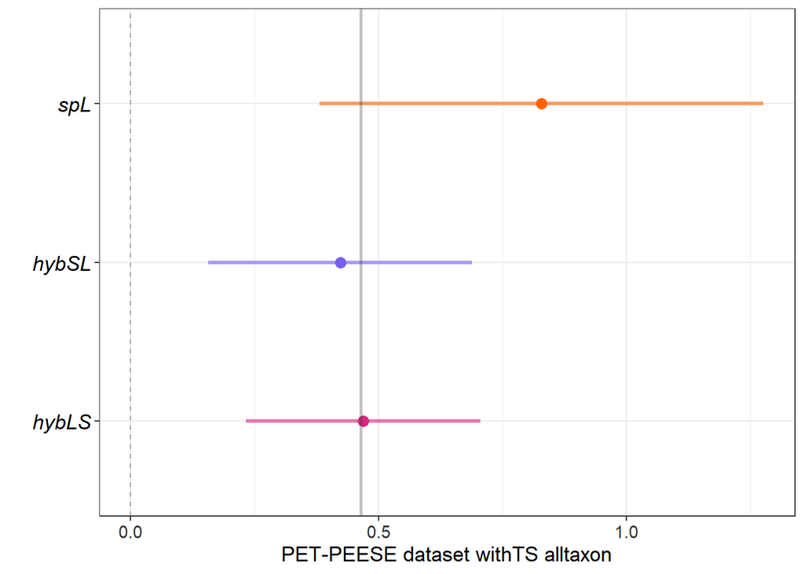

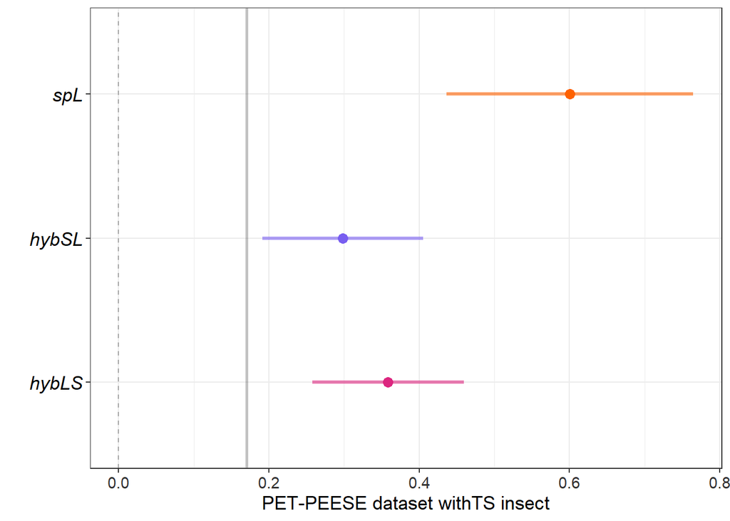

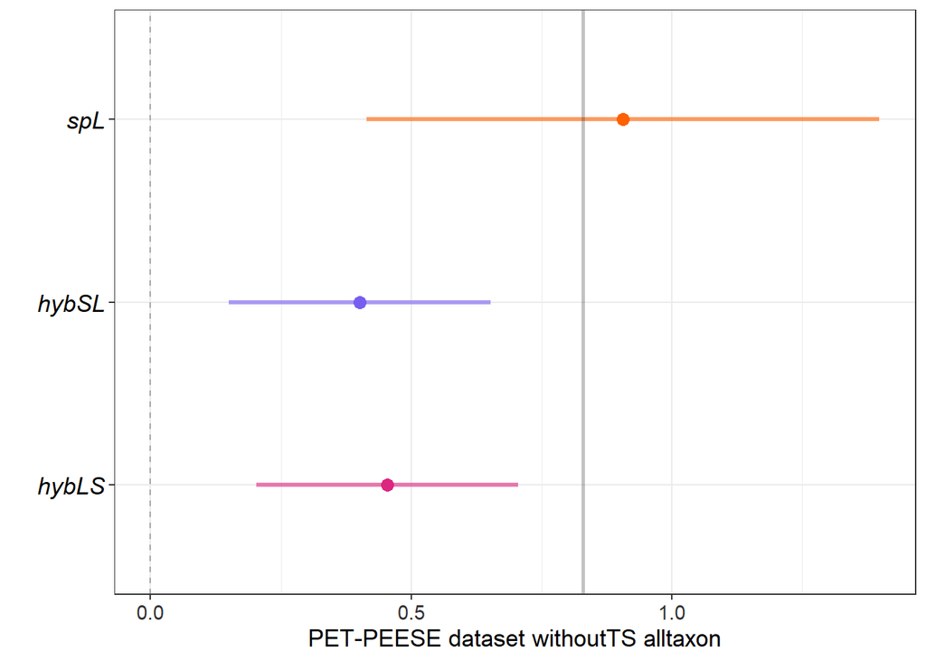

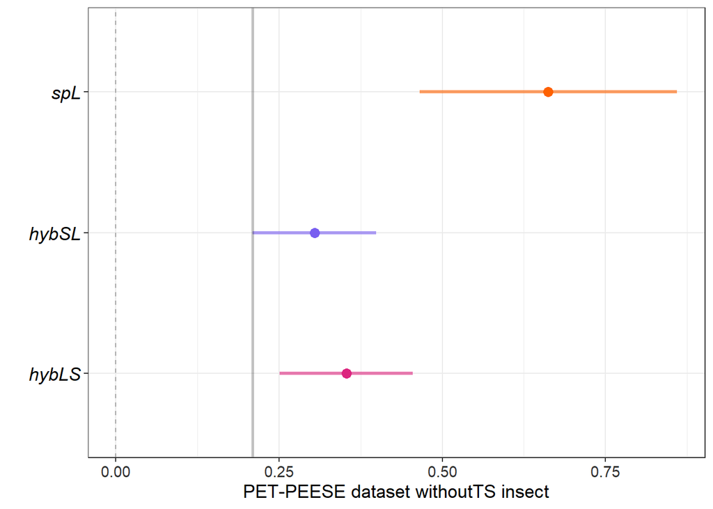

```r
> for (j in c("withTS", "withoutTS")) {
+   for (k in c("alltaxon", "insect")) {
+
+     if (k == "alltaxon") {
+       midparent.dat <- midparent %>%
+         filter(data.type == j)
+     } else {
+       midparent.dat <- midparent %>%
+         filter(data.type == j, insect == k)
+     }
+     # # Phylogenetic random meta-analysis for midparent
+     # midparent.random <- rma.mv(
+     #   yi = lnRR.midparent.es,
+     #   V = lnRR.sv,
+     #   data = midparent.dat %>% filter(cross == "midparent"),
+     #   method = "REML",
+     #   mods = ~ lnRR.sv,
+     #   random = list(~1 | spL.name, ~1 | Study.ID, ~1 | Cross.ID, ~1 | ES.ID),
+     #   R = list(spL.name = phylo_cor)
+     #   )
+     # ### Save model ###
+     # saveRDS(
+     #   midparent.random,
+     #   file = paste("../Analysis/Mean.PET-PEESE.midparent", j, k, "obj", sep = ".")
+     #   )
+
+     ### Load model ###
+     midparent.random <- readRDS(paste("../Analysis/Mean.PET-PEESE.midparent", j, k, "obj", sep = "."))
+     # creating summary table of results
+
+     midparent.ma <- get_reg(midparent.random) %>%
+       as.data.frame() %>%
+       mutate(
+         N = length(midparent.dat$ES.ID),
+         # I2 = I2(midparent.random)["I2_total"] %>% round(3),
+         cross = "midparent" # indicate cross (spL, hybLS, hybSL)
+         )
+
+     for (h in c("spL", "hybLS", "hybSL")) {
+
+       if (k == "alltaxon") {
+         dat <- with.without.TS %>%
+           filter(cross == h, data.type == j)
+       } else {
+         dat <- with.without.TS %>%
+           filter(cross == h, data.type == j, insect == k)
+       }
+       # # Phylogenetic random meta-analysis
+       # phyl.random <- rma.mv(
+       #   yi = lnRR.es, V = lnRR.sv,
+       #   data = dat, method = "REML",
+       #   mods = ~ lnRR.sv,
+       #   random = list(
+       #     ~1 | spL.name, ~1 | Study.ID, ~1 | Cross.ID, ~1 | ES.ID
+       #     ),
+       #   R = list(spL.name = phylo_cor)
+       #   )
+       # saveRDS(phyl.random,
+       #   file = paste("../Analysis/Mean.PET-PEESE", j, k, h, "obj", sep = "."))
+
+
+       ### Load model ###
+       phyl.random <- readRDS(paste("../Analysis/Mean.PET-PEESE", j, k, h, "obj", sep = "."))
+
+       assign(
+         paste("res", h, sep = "."),
+         get_reg(phyl.random) %>%
+           as.data.frame() %>%
+           mutate(
+             N = length(dat$ES.ID),
+             # I2 = I2(phyl.random)["I2_total"] %>% round(3),
+             cross = h # indicate cross (spL, hybLS, hybSL)
+             )
+           )
+
+     }
+
+     # Bind result of all crosses at each dataset
+     assign(
+       paste("res.ma", j,k, sep = "."),
+       res.ma <- bind_rows(
+         res.spL, res.hybLS, res.hybSL, midparent.ma
+         ) %>%
+         as.data.frame() %>%
+         within('Dataset' <- c(paste(j,k), rep("", length = 11))) # Show dataset name in first row
+     )
+
+     res.ma.plot <- res.ma %>%
+       filter(`Fixed effects` == "intrcpt") %>%
+       filter(cross != "midparent")
+
+     # creating a forest plot
+     plot.metamean <- ggplot(
+       data = res.ma.plot,
+       aes(x = Estimate, y = cross)
+       ) +
+       # scale_x_continuous(
+       #   limits = c(-1, 1),
+       #   breaks = seq(-1, 1, by = 0.25)
+       #   ) +
+       # Delete legend for colors
+       guides(fill = "none", colour = "none") +
+       # Confidential interval : thicker line
+       geom_errorbarh(
+         aes(xmin = LowerCI, xmax = UpperCI, color = cross),
+         height = 0, size = 1.2, alpha = 0.6
+         ) +
+       geom_vline(xintercept = 0, linetype = 2, colour = "black", alpha = 0.3) +
+       ### Estimate ###
+       geom_point(size = 3, shape = 21, aes(fill = cross, color = cross)) +
+       scale_color_manual(values = c("#DC267F", "#785EF0", "#FE6100")) +
+       scale_fill_manual(values = c("#DC267F", "#785EF0", "#FE6100")) +
+       ylab("") +
+       xlab(paste("PET-PEESE dataset", j,k)) +
+       # ### Midparent CI ###
+       # geom_rect(
+       #   aes(
+       #     xmin = res.ma[12, "LowerCI"],
+       #     xmax = res.ma[12, "UpperCI"],
+       #     ymin = -Inf, ymax = Inf
+       #     ),
+       #   fill="Grey 80", inherit.aes = FALSE
+       #   ) +
+       ### Midparent estimate ###
+       geom_vline(
+         xintercept = res.ma[12, "Estimate"], colour = "grey20",
+         alpha = 0.3, size = 1
+         ) +
+       theme_bw() +
+       theme(
+         axis.text.y = element_text(size = 13, color = "black", face = "italic"),
+         axis.text.x = element_text(size = 11, color = "grey20"),
+         axis.title = element_text(size = 13, color = "black"),
+         legend.position = c(0, 1),
+         legend.justification = c(0, 1),
+         legend.direction = "horizontal",
+         legend.background = element_blank()
+         )
+
+     print(plot.metamean)
+     #
+     #
+     # ggsave(
+     #   plot = plot.metamean,
+     #   file = paste("../Analysis/mean.general.metamean", j,k, "svg", sep = "."),
+     #   height = 5, width = 6
+     #   )
+   }
+ }
```

```r
> bind_rows(
+   res.ma.withTS.alltaxon, res.ma.withoutTS.alltaxon,
+   res.ma.withTS.insect, res.ma.withoutTS.insect
+   ) %>%
+   as.data.frame() %>%
+   mutate_at(vars('Estimate':'P'), as.numeric) %>%
+   select(Dataset, cross, 'Fixed effects', Estimate, UpperCI, LowerCI, contains("PR"), contains("V")) %>%
+   kable("html", digits = 3) %>% kable_styling("striped", position = "left")
```

| Dataset | cross | Fixed effects | Estimate | UpperCI | LowerCI |
| --- | --- | --- | --- | --- | --- |
| withTS alltaxon | spL |  |  |  |  |
|  | spL | intrcpt | 0.829 | 1.277 | 0.381 |
|  | spL | lnRR.sv | 0.520 | 1.980 | -0.940 |
|  | hybLS |  |  |  |  |
|  | hybLS | intrcpt | 0.469 | 0.706 | 0.233 |
|  | hybLS | lnRR.sv | 0.347 | 1.190 | -0.497 |
|  | hybSL |  |  |  |  |
|  | hybSL | intrcpt | 0.423 | 0.689 | 0.157 |
|  | hybSL | lnRR.sv | 0.272 | 1.356 | -0.811 |
|  | midparent |  |  |  |  |
|  | midparent | intrcpt | 0.542 | 0.863 | 0.221 |
|  | midparent | lnRR.sv | 0.464 | 1.744 | -0.815 |
| withoutTS alltaxon | spL |  |  |  |  |
|  | spL | intrcpt | 0.906 | 1.398 | 0.414 |
|  | spL | lnRR.sv | 0.792 | 2.692 | -1.109 |
|  | hybLS |  |  |  |  |
|  | hybLS | intrcpt | 0.454 | 0.706 | 0.203 |
|  | hybLS | lnRR.sv | 0.251 | 1.240 | -0.738 |
|  | hybSL |  |  |  |  |
|  | hybSL | intrcpt | 0.401 | 0.653 | 0.150 |
|  | hybSL | lnRR.sv | 0.723 | 1.998 | -0.553 |
|  | midparent |  |  |  |  |
|  | midparent | intrcpt | 0.595 | 0.947 | 0.243 |
|  | midparent | lnRR.sv | 0.829 | 2.548 | -0.889 |
| withTS insect | spL |  |  |  |  |
|  | spL | intrcpt | 0.601 | 0.765 | 0.437 |
|  | spL | lnRR.sv | 0.237 | 1.661 | -1.186 |
|  | hybLS |  |  |  |  |
|  | hybLS | intrcpt | 0.358 | 0.459 | 0.257 |
|  | hybLS | lnRR.sv | 0.214 | 1.046 | -0.618 |
|  | hybSL |  |  |  |  |
|  | hybSL | intrcpt | 0.298 | 0.406 | 0.191 |
|  | hybSL | lnRR.sv | -0.035 | 1.033 | -1.102 |
|  | midparent |  |  |  |  |
|  | midparent | intrcpt | 0.380 | 0.499 | 0.261 |
|  | midparent | lnRR.sv | 0.171 | 1.430 | -1.089 |
| withoutTS insect | spL |  |  |  |  |
|  | spL | intrcpt | 0.662 | 0.860 | 0.465 |
|  | spL | lnRR.sv | 0.213 | 2.092 | -1.666 |
|  | hybLS |  |  |  |  |
|  | hybLS | intrcpt | 0.353 | 0.455 | 0.251 |
|  | hybLS | lnRR.sv | 0.023 | 1.012 | -0.966 |
|  | hybSL |  |  |  |  |
|  | hybSL | intrcpt | 0.304 | 0.399 | 0.209 |
|  | hybSL | lnRR.sv | 0.148 | 1.439 | -1.143 |
|  | midparent |  |  |  |  |
|  | midparent | intrcpt | 0.421 | 0.566 | 0.277 |
|  | midparent | lnRR.sv | 0.209 | 1.929 | -1.510 |